# Designing for a better world: Accessibility

Mick McQuaid

2024-11-17

How to Start?

# AI isn’t helping (… much)

## Vendors tell you to kick back and let AI handle accessibility

- Yet manual intervention is always required
- Even the best AI tools don’t save you much time
- Yet your clients don’t understand why you can’t sprinkle magic fairy dust on your designs to make them accessible
- Use AI for individual empowerment

## We’re losing the struggle for accessibility

- WCAG is too complicated to understand, let alone implement
- Clients have a compliance mindset, rather than an anti-ableist mindset
- Technological development outpaces design—new things appear at a faster rate than we can design for them
- Universal design is a double-edged sword
- Did I mention that AI isn’t helping much?

## What can you do?

- You’re a communicator above all
- You naturally spend more time communicating the design than you do designing
- Ask your client if they’ve ever had a conversation about disability with a disabled person
- (Have you?)
- Humanize the importance of accessibility

## Examine yourself!

When you think of disability, do you see this or that?

[figure not shown]

[figure not shown]

## Examine yourself!

When you see this, do you think of accessibility?

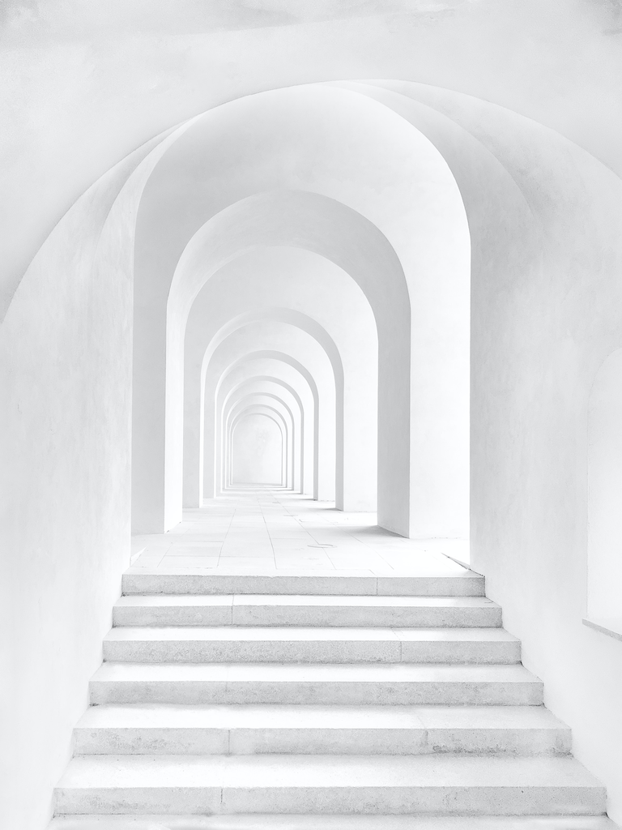

## Examine yourself!

When you think of disability, do you think of a spectrum?

[figure not shown]

## Good news, everyone!

[figure not shown]

- Title II of the ADA was released in April of this year (amended in June)
- Title II, Subpart H of the ADA means more clients
- Title II, Subpart H of the ADA means clients take accessibility more seriously and are more willing to budget for it

## But the bad news is

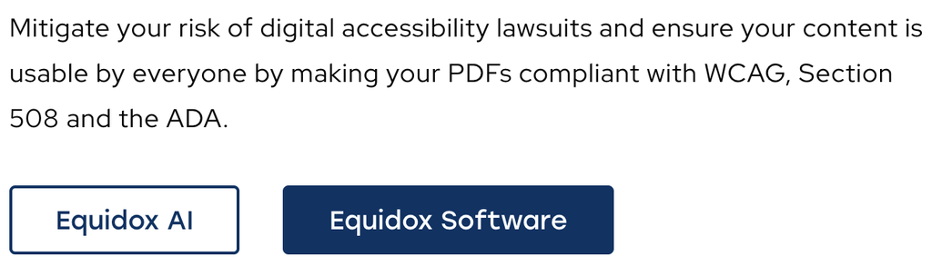

- Clients still have the compliance mindset, not the anti-ableist mindset
- You may need to communicate the difference to them
- You may need to recruit disabled people to design and test
- This is *extra* work on top of your current burdens

# We’re awakening to more challenges

## Neurodiverse communities

*genAI can be helpful!*

- ADHD: use genAI for note taking, task management, budgeting and meal planning
- Dyslexia: use genAI as a writing support
- Autism: use genAI for communication, ensuring intended tone
- Biases are a problem
- Neurodiverse communities build their own inclusive tools

# Takeaways

## How can you streamline your work?

- If you must remediate pdfs, use CommonLook PDF in preference to Acrobat alone
- Think of accessibility as a design principle rather than a set of activities
- Teach developers with templates (borrowed from usability)
- Treat participants well in your user studies so they’ll come back because disabled participants are hard to come by

## Above all, talk about accessibility

- to anyone who will listen
- remember the rarity of conversations with the disabled
- share shortcuts
- recruit disabled designers
- keep in mind that accessibility improves usability!

# For more

- visit the folder where this slideshow is stored for introductory slides about accessibility
  - use the *s* key on your keyboard for speaker’s notes and attributions
- attend ASSETS or review the work there
- have informal conversations with academics

# Please contact me!

email mcq@utexas.edu to share further ideas and questions

visit https://mickmcquaid.com and click on Accessibility

Thanks for listening!

END

# Colophon

This slideshow was produced using `quarto`

Fonts are *League Gothic* and *Lato*